# Take-home Exercise 1: Visual Analytics for Data Discovery

Profitability and volatility of a Spanish motor insurance portfolio

Author

Jedidiah Asaf

Published

May 24, 2026

Modified

July 4, 2026

# 1 Overview

Insurers routinely carry underperforming sub-portfolios whose drivers of poor profitability and high volatility are not immediately visible from aggregated KPIs. This study applies a **visual analytics workflow** to a real-world motor vehicle insurance portfolio from a Spanish non-life insurer (354,140 policy-years across 2022–2024) to:

1. Profile the distributions of numerical and categorical variables (**univariate**);
2. Identify and statistically validate factors that influence **profitability** (loss ratio) and **volatility** (severity dispersion, loss concentration) (**bivariate**).

The analysis is implemented entirely with the **tidyverse** family for data wrangling and **ggplot2** plus extensions (`ggridges`, `ggdist`, `patchwork`, `ggstatsplot`, `scales`) for visual analytics.

# 2 Data

The data is the open-access motor insurance portfolio published on Mendeley Data. It contains 47 variables grouped into:

- **Policy identifiers**: `insured_id`, `year`
- **Policy characteristics**: `policy_type`, `policy_status`, `business_type`, `payment_frequency`, `bonus_score`
- **Driver & vehicle**: `driver_age`, `vehicle_age`, `age_driving_licence`, `fuel_type`, `vehicle_value`, `seats`, `power_to_weight_ratio`, `vehicle_brand`
- **Geography**: `municipality_type`, `circulation_area`
- **Financials per coverage line** (liability, property damage, theft, fire, glass, legal protection, occupants): `_premium`, `_claims`, `_incurred`, `_exposure`

# 3 Loading packages

```r
pacman::p_load(
  tidyverse, lubridate, scales,
  ggridges, ggdist, ggstatsplot, patchwork, ggcorrplot, ggrepel,
  knitr, gt, skimr
)

theme_set(theme_minimal(base_size = 11) +
            theme(plot.title    = element_text(face = "bold", size = 13),
                  plot.subtitle = element_text(colour = "grey30"),
                  panel.grid.minor = element_blank()))
```

# 4 Data wrangling

## 4.1 Import

The source file uses a semicolon (`;`) field separator and dot decimal mark. `readr::read_delim()` handles this without locale tweaks.

```r
mi_raw <- read_delim(
  "data/motor_insurance.csv",
  delim = ";",
  show_col_types = FALSE
)

dim(mi_raw)
```

```
[1] 354140     47
```

## 4.2 Quality checks

```r
mi_raw |>
  summarise(across(everything(), ~ sum(is.na(.)))) |>
  pivot_longer(everything(), names_to = "variable", values_to = "n_missing") |>
  filter(n_missing > 0) |>
  arrange(desc(n_missing)) |>
  gt() |>
  tab_header(title = "Variables with missing values")
```

Variables with missing values

| variable | n_missing |
| --- | --- |
| fuel_type | 1287 |
| vehicle_value | 513 |
| vehicle_age | 2 |
| age_driving_licence | 2 |

Only four variables have missing values, all at very low prevalence (`fuel_type` 0.36%, `vehicle_value` 0.14%, `vehicle_age` / `age_driving_licence` 2 records each). They are retained but flagged.

## 4.3 Type conversion & re-coding

To support meaningful visual encoding, character codes are mapped to descriptive labels and converted to ordered factors where natural ordering exists (e.g. payment frequency).

```r
mi <- mi_raw |>
  mutate(
    year             = factor(year),
    policy_type      = recode(policy_type,
                              "CC"="Basic",
                              "TP"="Third-party",
                              "TPG"="Third-party+Glass",
                              "COMP_N"="Comp. (basic)",
                              "COMP_E"="Comp. (extended)") |>
                       fct_relevel("Third-party","Third-party+Glass","Basic",
                                   "Comp. (basic)","Comp. (extended)"),
    policy_status    = recode(policy_status, "A"="Active", "C"="Cancelled"),
    business_type    = recode(business_type, "NB"="New business", "P"="Renewal"),
    payment_frequency= recode(payment_frequency,
                              "A"="Annual","S"="Semi-annual","Q"="Quarterly") |>
                       fct_relevel("Annual","Semi-annual","Quarterly"),
    bonus_score      = recode(bonus_score, "G"="Good","N"="Neutral","B"="Bad") |>
                       fct_relevel("Good","Neutral","Bad"),
    fuel_type        = recode(fuel_type, "D"="Diesel","G"="Gasoline"),
    municipality_type= recode(municipality_type,
                              "C"="Capital","I"="Inland","IS"="Island"),
    circulation_area = recode(circulation_area, "U"="Urban","R"="Rural")
  )
```

## 4.4 Derive analytical measures

Three actuarial KPIs are derived. The denominator guards prevent divisions by zero.

```r
mi <- mi |>
  mutate(
    loss_ratio      = if_else(total_premium  > 0, total_incurred / total_premium,  NA_real_),
    claim_frequency = if_else(total_exposure > 0, total_claims    / total_exposure, NA_real_),
    claim_severity  = if_else(total_claims   > 0, total_incurred  / total_claims,   NA_real_),
    had_claim       = total_claims > 0,
    driver_age_band = cut(driver_age,
                          breaks = c(17,25,35,50,65,90),
                          labels = c("18-25","26-35","36-50","51-65","66+")),
    vehicle_age_band= cut(vehicle_age,
                          breaks = c(-1,5,10,15,25,100),
                          labels = c("0-5","6-10","11-15","16-25","26+"))
  )

skimr::skim(mi |> select(loss_ratio, claim_frequency, claim_severity))
```

Data summary

| Name | select(mi, loss_ratio, cl… |
| --- | --- |
| Number of rows | 354140 |
| Number of columns | 3 |
| _______________________ |  |
| Column type frequency: |  |
| numeric | 3 |
| ________________________ |  |
| Group variables | None |

**Variable type: numeric**

| skim_variable | n_missing | complete_rate | mean | sd | p0 | p25 | p50 | p75 | p100 | hist |
| --- | --- | --- | --- | --- | --- | --- | --- | --- | --- | --- |
| loss_ratio | 49 | 1.00 | 0.79 | 22.55 | 0 | 0.0 | 0.00 | 0 | 11348.86 | ▇▁▁▁▁ |
| claim_frequency | 49 | 1.00 | 0.32 | 1.99 | 0 | 0.0 | 0.00 | 0 | 486.67 | ▇▁▁▁▁ |
| claim_severity | 303333 | 0.14 | 848.03 | 2927.33 | 0 | 119.7 | 498.35 | 1012 | 244091.25 | ▇▁▁▁▁ |

**Note**

**Why aggregated loss ratio rather than the policy mean?** The aggregated (portfolio) loss ratio is $\sum I / \sum P$, which is the actuarially correct measure because losses and premiums must be summed before being divided. The arithmetic mean of policy-level ratios is heavily distorted by 88% of policies having `loss_ratio == 0`.

# 5 Univariate analysis

## 5.1 Numerical variables

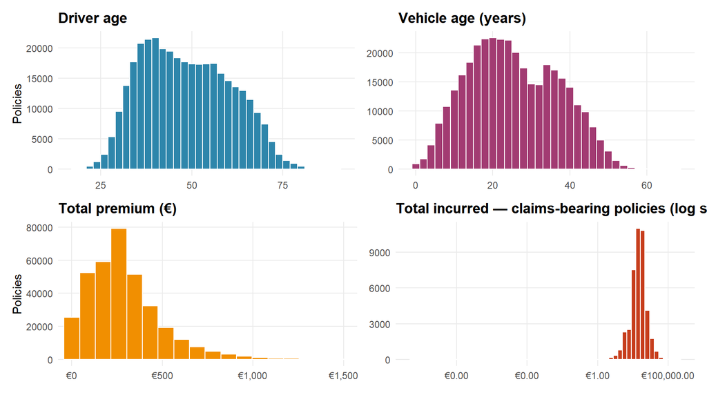

```r
p1 <- ggplot(mi, aes(driver_age)) +
  geom_histogram(binwidth = 2, fill = "#2E86AB", colour = "white") +
  labs(title = "Driver age", x = NULL, y = "Policies")

p2 <- ggplot(mi, aes(vehicle_age)) +
  geom_histogram(binwidth = 2, fill = "#A23B72", colour = "white") +
  labs(title = "Vehicle age (years)", x = NULL, y = NULL)

p3 <- ggplot(mi, aes(total_premium)) +
  geom_histogram(bins = 60, fill = "#F18F01", colour = "white") +
  scale_x_continuous(labels = label_dollar(prefix = "€", big.mark=",")) +
  coord_cartesian(xlim = c(0, 1500)) +
  labs(title = "Total premium (€)", x = NULL, y = "Policies")

p4 <- ggplot(mi |> filter(total_incurred > 0),
             aes(total_incurred)) +
  geom_histogram(bins = 60, fill = "#C73E1D", colour = "white") +
  scale_x_log10(labels = label_dollar(prefix = "€", big.mark=",")) +
  labs(title = "Total incurred — claims-bearing policies (log scale)",
       x = NULL, y = NULL)

(p1 | p2) / (p3 | p4)
```

The premium distribution is bounded near zero with a long tail; **88% of policies have zero incurred** (no claim in the period), and among the 12% with claims the log-scaled distribution is approximately log-normal — typical of motor portfolios. This shape is the root cause of the portfolio’s **volatility**: the loss outcome is dominated by a thin right tail.

## 5.2 Categorical variables — portfolio composition

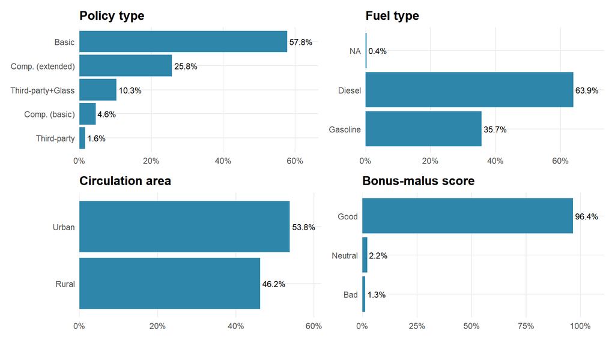

Figure 2: Portfolio mix by key categorical variables.

```r
plot_share <- function(var, title){
  mi |>
    count(.data[[var]]) |>
    mutate(share = n/sum(n)) |>
    ggplot(aes(reorder(.data[[var]], share), share)) +
    geom_col(fill = "#2E86AB") +
    geom_text(aes(label = percent(share, 0.1)), hjust = -0.1, size = 3) +
    scale_y_continuous(labels = percent, expand = expansion(c(0,0.15))) +
    coord_flip() +
    labs(title = title, x = NULL, y = NULL)
}

(plot_share("policy_type","Policy type") |
   plot_share("fuel_type","Fuel type")) /
(plot_share("circulation_area","Circulation area") |
   plot_share("bonus_score","Bonus-malus score"))
```

The portfolio is **dominated by Basic (CC) policies (58%)** and the **bonus-malus distribution is extremely skewed toward Good drivers (96%)**. This imbalance limits the discriminating power of bonus-malus segmentation and motivates the search for additional risk factors.

# 6 Bivariate analysis — Profitability

The **loss ratio (LR)** is the primary profitability indicator. An LR above ~70–75% typically signals an unprofitable book once expenses are loaded.

## 6.1 Trend by underwriting year

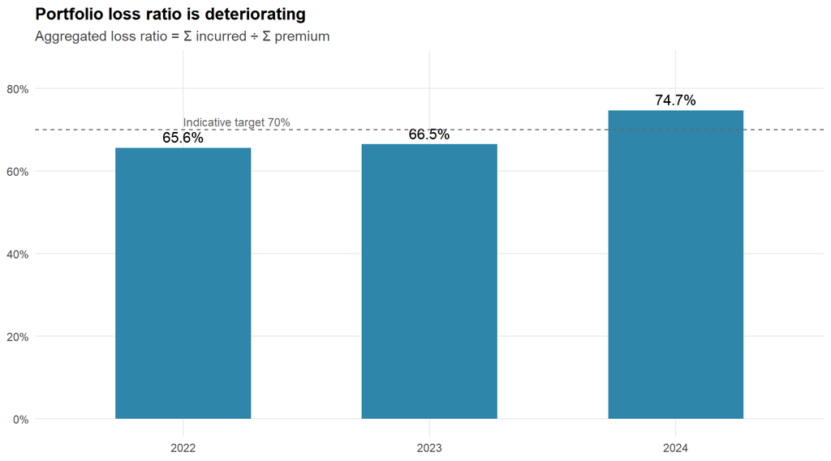

Figure 3: Aggregated loss ratio by underwriting year — material deterioration in 2024.

```r
lr_year <- mi |>
  group_by(year) |>
  summarise(lr = sum(total_incurred)/sum(total_premium),
            premium_m = sum(total_premium)/1e6,
            .groups = "drop")

ggplot(lr_year, aes(year, lr)) +
  geom_col(fill = "#2E86AB", width = 0.55) +
  geom_text(aes(label = percent(lr, 0.1)), vjust = -0.5, size = 4) +
  geom_hline(yintercept = 0.70, linetype = 2, colour = "grey40") +
  annotate("text", x = 1, y = 0.72, label = "Indicative target 70%",
           hjust = 0, size = 3.2, colour = "grey40") +
  scale_y_continuous(labels = percent, limits = c(0, 0.85)) +
  labs(title = "Portfolio loss ratio is deteriorating",
       subtitle = "Aggregated loss ratio = Σ incurred ÷ Σ premium",
       x = NULL, y = NULL)
```

The portfolio LR moves from **65.6% (2022) to 74.7% (2024)** — a **9-point deterioration in two years** that is the central finding of the study. Combined with typical expense ratios of 25–30%, the 2024 combined ratio is plausibly above 100%.

## 6.2 Loss ratio by policy type

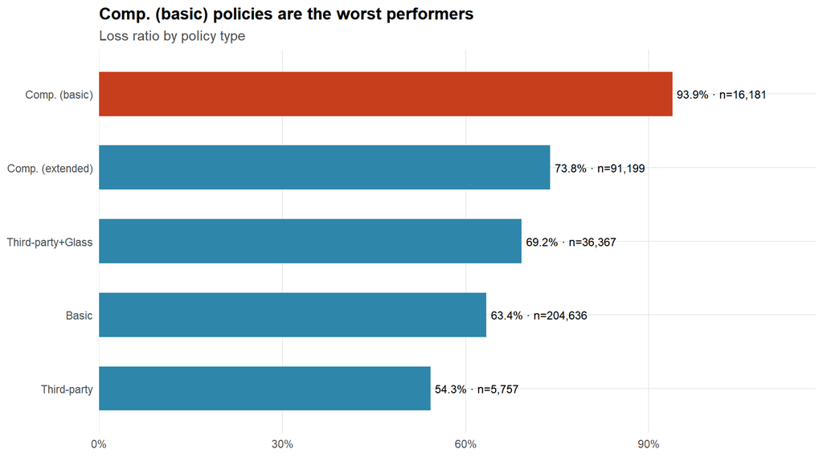

Figure 4: Loss ratio by policy type. COMP_N (basic comprehensive) is the standout under-performer.

```r
lr_pol <- mi |>
  group_by(policy_type) |>
  summarise(n = n(),
            premium = sum(total_premium),
            lr = sum(total_incurred)/sum(total_premium),
            .groups = "drop")

ggplot(lr_pol, aes(reorder(policy_type, lr), lr)) +
  geom_col(aes(fill = lr > 0.75), width = 0.6) +
  geom_text(aes(label = paste0(percent(lr, 0.1),
                               " · n=", scales::comma(n))),
            hjust = -0.05, size = 3.2) +
  scale_fill_manual(values = c("TRUE"="#C73E1D","FALSE"="#2E86AB"), guide = "none") +
  scale_y_continuous(labels = percent, expand = expansion(c(0, .25))) +
  coord_flip() +
  labs(title = "Comp. (basic) policies are the worst performers",
       subtitle = "Loss ratio by policy type",
       x = NULL, y = NULL)
```

## 6.3 Loss ratio by risk and behavioural drivers

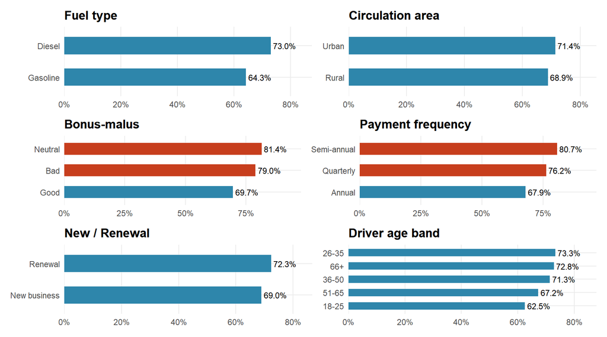

Figure 5: Loss ratio across the principal segmentation dimensions.

```r
plot_lr <- function(var, title){
  mi |>
    group_by(.data[[var]]) |>
    summarise(lr = sum(total_incurred)/sum(total_premium),
              n  = n(), .groups = "drop") |>
    filter(!is.na(.data[[var]])) |>
    ggplot(aes(reorder(.data[[var]], lr), lr)) +
    geom_col(aes(fill = lr > 0.75), width = 0.55) +
    geom_text(aes(label = percent(lr, 0.1)), hjust = -0.1, size = 3) +
    scale_fill_manual(values=c("TRUE"="#C73E1D","FALSE"="#2E86AB"), guide="none") +
    scale_y_continuous(labels = percent, expand = expansion(c(0,.2))) +
    coord_flip() + labs(title = title, x = NULL, y = NULL)
}

(plot_lr("fuel_type","Fuel type") |
   plot_lr("circulation_area","Circulation area")) /
(plot_lr("bonus_score","Bonus-malus") |
   plot_lr("payment_frequency","Payment frequency")) /
(plot_lr("business_type","New / Renewal") |
   plot_lr("driver_age_band","Driver age band"))
```

## 6.4 Vehicle brand — top under-performers

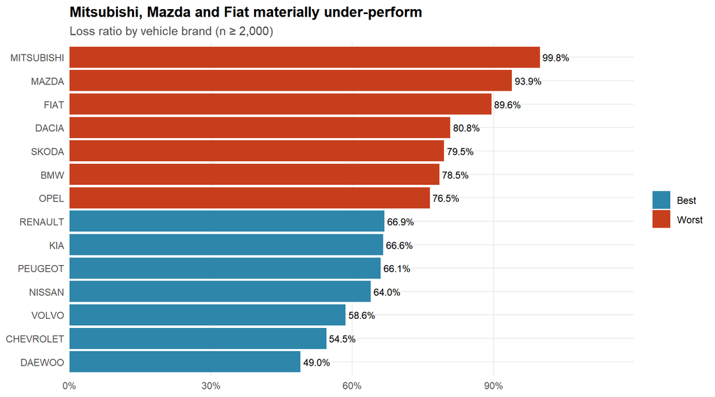

Figure 6: Brands with at least 2,000 policy-years, ranked by loss ratio.

```r
brand_lr <- mi |>
  group_by(vehicle_brand) |>
  summarise(n = n(),
            premium = sum(total_premium),
            lr = sum(total_incurred)/sum(total_premium),
            .groups = "drop") |>
  filter(n >= 2000)

bind_rows(slice_max(brand_lr, lr, n = 7) |> mutate(grp = "Worst"),
          slice_min(brand_lr, lr, n = 7) |> mutate(grp = "Best")) |>
  ggplot(aes(reorder(vehicle_brand, lr), lr, fill = grp)) +
  geom_col() +
  geom_text(aes(label = percent(lr, 0.1)), hjust = -0.1, size = 3) +
  scale_fill_manual(values = c("Worst"="#C73E1D","Best"="#2E86AB")) +
  scale_y_continuous(labels = percent, expand = expansion(c(0,.2))) +
  coord_flip() +
  labs(title = "Mitsubishi, Mazda and Fiat materially under-perform",
       subtitle = "Loss ratio by vehicle brand (n ≥ 2,000)",
       x = NULL, y = NULL, fill = NULL)
```

# 7 Bivariate analysis — Volatility

Portfolio volatility is driven by **severity** (the size of individual losses) more than by claim frequency.

## 7.1 Claim severity distribution

[figure not shown]

Figure 7: Claim severity is approximately log-normal with an extreme right tail.

```r
mi_claims <- mi |>
  filter(had_claim, !is.na(claim_severity), claim_severity > 0, is.finite(claim_severity))

ggplot(mi_claims, aes(claim_severity)) +
  geom_histogram(bins = 60, fill = "#A23B72", colour = "white") +
  scale_x_log10(labels = label_dollar(prefix = "€", big.mark=",")) +
  geom_vline(xintercept = median(mi_claims$claim_severity), linetype = 2) +
  annotate("text",
           x = median(mi_claims$claim_severity)*1.15,
           y = 4000,
           label = paste0("Median €",
                          format(round(median(mi_claims$claim_severity)),
                                 big.mark=",")),
           hjust = 0, size = 3.3) +
  labs(title = "Claim severity distribution (log scale)",
       subtitle = "Median €498 · 95th percentile €2,429 · max €244,091",
       x = "Severity per claim", y = "Claims")
```

## 7.2 Loss concentration

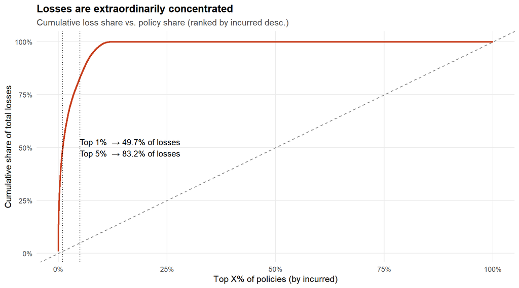

Figure 8: Loss concentration curve. The vertical lines mark the 1% and 5% policy thresholds.

```r
sorted <- mi |>
  arrange(desc(total_incurred)) |>
  mutate(rank_pct = row_number()/n(),
         cum_loss_pct = cumsum(total_incurred)/sum(total_incurred))

ggplot(sorted, aes(rank_pct, cum_loss_pct)) +
  geom_line(colour = "#C73E1D", linewidth = 0.9) +
  geom_abline(slope = 1, intercept = 0, linetype = 2, colour = "grey50") +
  geom_vline(xintercept = c(0.01, 0.05), linetype = 3) +
  annotate("text", x = 0.05, y = 0.50,
           label = "Top 1%  → 49.7% of losses\nTop 5%  → 83.2% of losses",
           hjust = 0, size = 3.5) +
  scale_x_continuous(labels = percent) +
  scale_y_continuous(labels = percent) +
  labs(title = "Losses are extraordinarily concentrated",
       subtitle = "Cumulative loss share vs. policy share (ranked by incurred desc.)",
       x = "Top X% of policies (by incurred)", y = "Cumulative share of total losses")
```

**Half of all losses are produced by just 1% of policies** and **83% by 5%**. Volatility management is therefore largely about identifying and pricing this thin tail.

## 7.3 Severity by segment

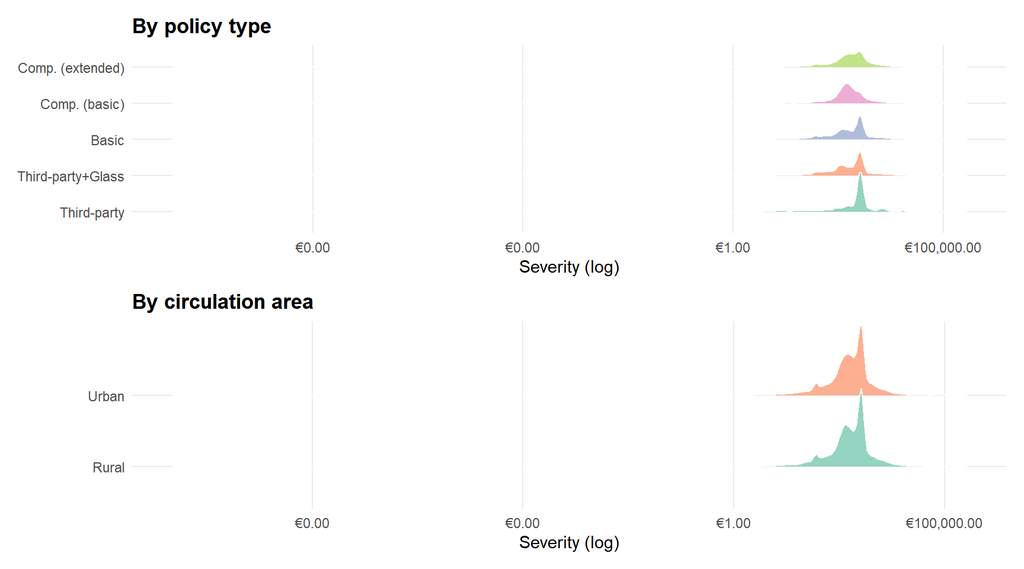

Figure 9: Claim severity by policy type and circulation area (ridge plots, log scale).

```r
p_a <- ggplot(mi_claims, aes(x = claim_severity, y = policy_type, fill = policy_type)) +
  geom_density_ridges(alpha = 0.7, scale = 1.1, colour = "white") +
  scale_x_log10(labels = label_dollar(prefix = "€", big.mark = ",")) +
  scale_fill_brewer(palette = "Set2", guide = "none") +
  labs(title = "By policy type", x = "Severity (log)", y = NULL)

p_b <- ggplot(mi_claims, aes(x = claim_severity, y = circulation_area, fill = circulation_area)) +
  geom_density_ridges(alpha = 0.7, scale = 1.1, colour = "white") +
  scale_x_log10(labels = label_dollar(prefix = "€", big.mark = ",")) +
  scale_fill_brewer(palette = "Set2", guide = "none") +
  labs(title = "By circulation area", x = "Severity (log)", y = NULL)

p_a / p_b
```

## 7.4 Frequency × severity heatmap by driver and vehicle age

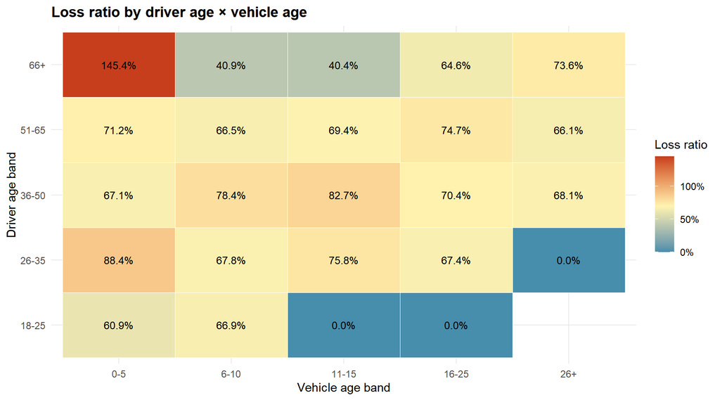

Figure 10: Aggregated loss ratio by combinations of driver age and vehicle age.

```r
heat <- mi |>
  filter(!is.na(driver_age_band), !is.na(vehicle_age_band)) |>
  group_by(driver_age_band, vehicle_age_band) |>
  summarise(lr = sum(total_incurred)/sum(total_premium),
            n  = n(), .groups = "drop")

ggplot(heat, aes(vehicle_age_band, driver_age_band, fill = lr)) +
  geom_tile(colour = "white") +
  geom_text(aes(label = percent(lr, 0.1)), size = 3.3) +
  scale_fill_gradient2(low = "#2E86AB", mid = "#FFF3B0", high = "#C73E1D",
                       midpoint = 0.70, labels = percent) +
  labs(title = "Loss ratio by driver age × vehicle age",
       x = "Vehicle age band", y = "Driver age band", fill = "Loss ratio")
```

# 8 Statistical validation

Visual differences are validated with non-parametric tests appropriate to the highly skewed loss data.

## 8.1 Independence of having-a-claim from segmentation variables

```r
chi_test <- function(var){
  tab <- table(mi[[var]], mi$had_claim)
  ct <- chisq.test(tab)
  tibble(variable = var,
         chi2 = round(ct$statistic, 1),
         df = ct$parameter,
         p_value = format.pval(ct$p.value, digits = 2, eps = 1e-300),
         cramers_v = round(sqrt(ct$statistic / (sum(tab) * (min(dim(tab))-1))), 3))
}

map_dfr(c("policy_type","fuel_type","circulation_area",
          "bonus_score","payment_frequency","business_type"), chi_test) |>
  gt() |>
  tab_header(title = "Chi-square: claim occurrence vs. categorical drivers")
```

Chi-square: claim occurrence vs. categorical drivers

| variable | chi2 | df | p_value | cramers_v |
| --- | --- | --- | --- | --- |
| policy_type | 6638.4 | 4 | <1e-300 | 0.137 |
| fuel_type | 817.1 | 1 | 1e-179 | 0.048 |
| circulation_area | 225.9 | 1 | 4.7e-51 | 0.025 |
| bonus_score | 297.2 | 2 | 2.9e-65 | 0.029 |
| payment_frequency | 463.9 | 2 | 1.8e-101 | 0.036 |
| business_type | 2317.9 | 1 | <1e-300 | 0.081 |

All factors reject the null of independence at p < 0.001. Effect sizes (Cramer’s V) are small individually but consistent.

## 8.2 Severity differences across policy types

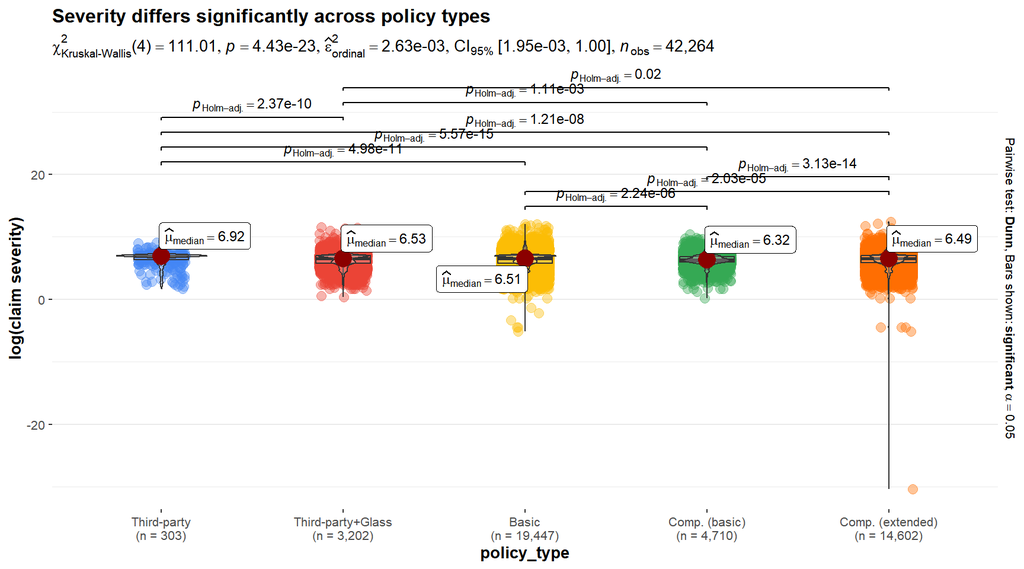

Figure 11: Built-in statistical annotation via ggstatsplot — log severity by policy type.

```r
ggbetweenstats(
  data = mi_claims |> mutate(log_sev = log(claim_severity)),
  x = policy_type, y = log_sev,
  type = "nonparametric",
  pairwise.display = "significant",
  results.subtitle = TRUE,
  centrality.label.args = list(size = 3)
) +
  labs(y = "log(claim severity)", title = "Severity differs significantly across policy types")
```

# 9 Discussion

The combination of visual exploration and lightweight statistical validation yields a coherent narrative:

1. **Profitability is deteriorating**: portfolio LR moves from 65.6% to 74.7% in two years.
2. **One product line is the prime driver**: `Comp. (basic)` (93.9% LR) is the single largest contributor to underperformance.
3. **Behavioural signals matter**: payment frequency and renewal status both indicate adverse selection that the current pricing does not fully reflect.
4. **Risk is concentrated**: 5% of policies generate 83% of losses, so tail-pricing accuracy dominates portfolio results.
5. **Bonus-malus is under-utilised**: 96% of policyholders sit in the “Good” tier, leaving the system unable to discriminate.

Recommended actions: re-price `Comp. (basic)` and diesel vehicles; differentiate by payment frequency; widen the bonus-malus scale; deploy a tail-aware monitoring dashboard.

# 10 References

- Quesada-Molina, J.J. et al. — *Spanish motor insurance portfolio dataset*. Mendeley Data.
- Wickham, H. — *ggplot2: Elegant Graphics for Data Analysis* (3rd ed.).
- Patil, I. — *ggstatsplot: visualizations with statistical details* (JOSS, 2021).
- Wilke, C.O. — *Fundamentals of Data Visualization*.
- McKinsey & Company — *Advanced analytics: unlocking new frontiers in P&C insurance*.